# London Marathon Data Analysis

Team 6

Longxiang Wu, Navpreet Singh Sandhu, Shengle Yan

2023-12-13

```r
library(tidyverse)
library(ggplot2)
library(dplyr)
library(gridExtra)
library(forecast)
remotes::install_github("nrennie/LondonMarathon")
data(winners, package = "LondonMarathon")
data(london_marathon, package = "LondonMarathon")
```

# Project outline

## Introduction

### What is the data about?

The London Marathon, or the TCS London Marathon, is a truly special event that brings people from all walks of life together. It was the brainchild of visionaries Chris Brasher and John Disley back in 1981 and has since become the UK’s second-largest annual road race, second only to the famous Great North Run in Newcastle.

Usually happening in April, the marathon had a temporary switch to October in 2020, 2021, and 2022 due to the challenges posed by the COVID-19 pandemic. The course itself is known for its mostly flat terrain, winding its way around the beautiful River Thames, starting at Blackheath and ending with a grand finish at The Mall.

But the London Marathon isn’t just a race; it’s a melting pot of experiences. There’s the mass race, where people of all fitness levels challenge themselves and relish the thrill of completing a marathon. For elite long-distance runners, both men and women, there are professional races showcasing top-tier athleticism. Wheelchair races provide a platform for elite-level competition among both men and women.

Now, let’s dive into the details of the marathon with the comprehensive data:

London Marathon Data:

- This dataset spills the beans on everything from the number of applicants to accepted participants, starters, finishers, funds raised, and the official charities associated with each year.

Winner Data:

- The second set of data gives us the lowdown on the winners in different categories over the years, including details like the category, year, the winning athlete’s name, nationality, and their finishing time.

What truly sets the London Marathon apart is its heartwarming philanthropic side. Participants aren’t just running for personal glory; they’re making a difference. Since its start, the marathon has raised over £1 billion for various charities. In 2019 alone, an incredible £66.4 million was raised, marking it as the highest single-day fundraising event in the marathon’s history.

So, as the London Marathon continues to capture hearts and inspire runners worldwide, it’s not just a race; it’s a legacy of community, achievement.

### Questions that we will look at and the methods we used

1. Analyzing Trends in Winning Times Over the Years: Our examination of winning times involves creating time series plots for each category or utilizing regression analysis to identify significant trends. Through careful comparison and the use of visualizations, we aim to uncover patterns and changes in winning times across various categories. Exploring Wheelchair Winners’ Performances: Shifting our focus to inclusivity, we analyze the performances of wheelchair winners to understand how their achievements have evolved. A detailed examination of winning times helps us visualize trends, celebrating the success of wheelchair participants in the marathon.
2. Comparing Winning Times Between Categories: Using t-tests or analysis of variance (ANOVA), we compare winning times between different categories such as Men vs. Women and Wheelchair Men vs. Wheelchair Women. This analysis enables the exploration of variations in performance and identification of any significant differences between these categories.
3. Correlation Analysis: To delve deeper into the relationships within the data, we conduct correlation analysis.
4. In our exploration of the rich history of the London Marathon, we delve into a detailed examination of different aspects. To begin, let’s uncover the evolving trends in marathon participation over the years by closely examining changes in the number of applicants and accepted participants. To give these numbers context and meaning, we calculate the percentage of participants who moved from being accepted to actually starting the race and, subsequently, the percentage of those starters who successfully finished. This analysis aims to reveal any noticeable trends or patterns, breathing life into the raw numbers.

In the realm of inclusivity, we shift our focus to wheelchair winners, seeking to understand how their performances have evolved over the years. Through a detailed analysis of winning times, we aim to visualize trends and patterns, celebrating the achievements of wheelchair participants in the marathon.

Turning our attention to the marathon heroes, we delve into the winner analysis. The spotlight is on the most successful marathon winners, and we aim to understand how their performances have evolved over time. By examining variables such as nationality, winning times, and identifying any discernible patterns, Visualizing winning times over the years adds a vivid layer to this exploration.

In the financial realm, we track the yearly fundraising growth, exploring how the total fundraising amount has changed annually. Utilizing a line chart, we aim to capture the financial heartbeat of the London Marathon, identifying any significant spikes or drops and understanding the financial narrative that accompanies this iconic event.

### What information does the data contain? Cases, variables? How was it collected?

The data provided gives us insights into the London Marathon, offering details on the number of applicants, accepted participants, starters, finishers, funds raised, and the official charities involved for each year. Additionally, we have separate information on the winners across different categories such as Men, Women, Wheelchair Men, and Wheelchair Women throughout the years.

Let’s break down the key aspects:

Cases: Each row in the datasets represents a specific year of the London Marathon. There are 42 entries in the “London Marathon Data” and 165 entries in the “Winner.csv” data.

Variables in London Marathon Data:

- Date: Reflecting the date of the London Marathon.
- Year: Indicating the corresponding year of the London Marathon.
- Applicants: The count of individuals applying to participate in the marathon.
- Accepted: The number of applicants who secured a spot to participate.
- Starters: The count of participants who initiated the marathon.
- Finishers: The number of participants successfully completing the marathon.
- Raised: The total amount of money raised during the marathon.
- Official Charity: The designated charity associated with the marathon for that specific year.

Variables in Winner Data:

- Category: Specifies the category of the winner (Men, Women, Wheelchair Men, Wheelchair Women).
- Year: Denoting the year when the London Marathon took place.
- Athlete: The name of the winning athlete.
- Nationality: The country of origin of the winning athlete.
- Time: The duration taken by the winning athlete to complete the marathon.

How was it collected?

- The data seems to have been collected over the years, possibly sourced from official records, the official website of the London Marathon, event organizers, media outlets such as BBC, and other reliable sources associated with the event. The information could have been compiled from participant registrations, event statistics, official reports, and media coverage.

## Data Wrangling

As the datasets are different aspects of information about london marathon, we choose not to combine them but analyze them seperately.

### Methods dealing with missing values

1. Deleting
2. Interpolation
- mean
- KNN
- stochastic interpolation
- EM
- Lagrange interpolation
- Hot-Deck imputation
3. Multiple Interpolation
- predictive mean matching
- propensity score
- Markov Chain Monte Carlo
4. Models
- regression
- Bayesian models
- Random Forest
- Decision Tree
5. Mapping to higher dimensions
6. Stochastic filling
- Bayesian bootstrap
- Approximate Bayesian Bootstrap
6. Not dealing with

### Do variables have appropriate type?

```r
library(knitr)
table <- data.frame('Column'=c('Category','Year','Athlete','Nationality','Time'), 'Class'=c('character','integer','character','character','character'), 'Description'=c('Category of race','Year','Name of the winner','Nationality of the winner','Winning time'),'Example'=c('Men',1981,'Dick Beardsley(Tie)','United States', '02:11:48'))
kable(table, caption = "Winners")
```

Winners

[output not shown]

```r
table2 <- data.frame('Column'=c('Date','Year','Applicants','Accepted','Starters','Finishers','Raised','Official.charity'),'Class'=c('character','integer','integer','integer','integer','integer','integer','character'),'Description'=c('Date of the race','Year','Number of people who applied','Number of people accepted','Number of people who started','Number of people who finished','Amount raised for charity(£ millions)','Official charity'),'Example'=c('1981-03-29','1981','20000','7747','7055','6255','46.5','SportsAid'))
kable(table2, caption = "London Marathon")
```

London Marathon

[output not shown]

## Winners(analysis & conclusions)

### Anlysis of winners dataset

Overview of the dataset

```r
head(winners)
```

```
## # A tibble: 6 × 5
##   Category  Year Athlete              Nationality    Time
##   <chr>    <dbl> <chr>                <chr>          <times>
## 1 Men       1981 Dick Beardsley (Tie) United States  0.09152778
## 2 Men       1981 Inge Simonsen (Tie)  Norway         0.09152778
## 3 Men       1982 Hugh Jones           United Kingdom 0.08986111
## 4 Men       1983 Mike Gratton         United Kingdom 0.09008102
## 5 Men       1984 Charlie Spedding     United Kingdom 0.09024306
## 6 Men       1985 Steve Jones          United Kingdom 0.08907407
```

#### Trends in winning times over the year

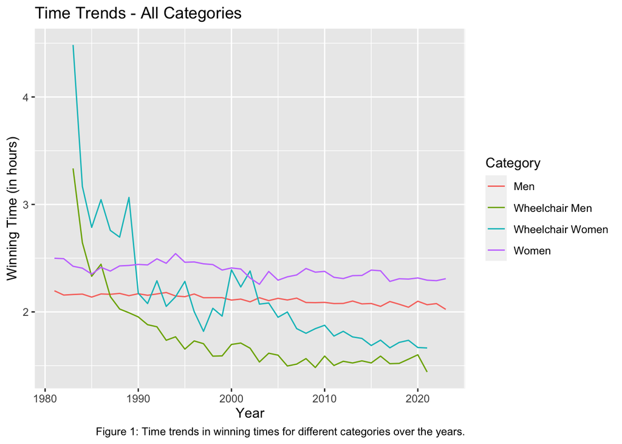

```r
winners_data <- winners |> mutate(Time=24*Time)

winners_data$Year <- as.numeric(winners_data$Year)
winners_data$Time <- as.numeric(winners_data$Time)

# Create time series plots for all categories with captions
ggplot(winners_data, aes(x = Year, y = Time, color = Category)) +
  geom_line() +
  ggtitle("Time Trends - All Categories") +
  xlab("Year") +
  ylab("Winning Time (in hours)") +
  labs(caption = "Figure 1: Time trends in winning times for different categories over the years.")
```

The overall trend suggests that there has been an improvement in athletic performance across all categories over the years, with notable drops in winning times.

#### Compare winning times between different categories (i.e. How much difference there is between performance of men and women?)

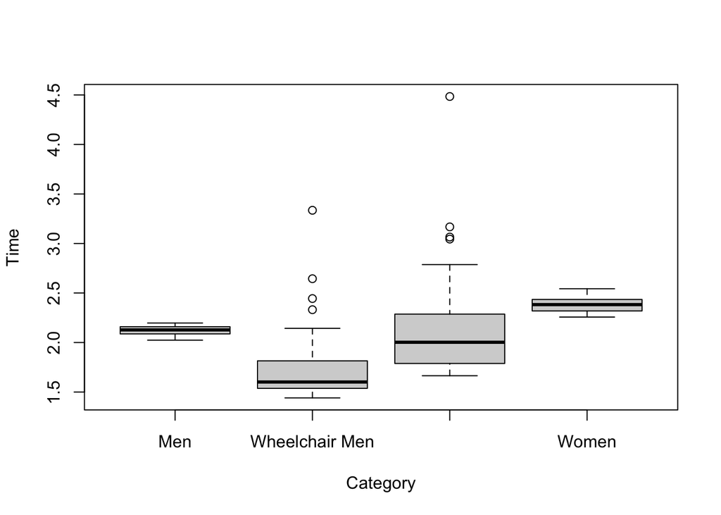

```r
boxplot(Time ~ Category, data = winners_data)
```

```r
# t-test for Men vs. Women
t_test_men_women <- t.test(Time ~ Category, data = subset(winners_data, Category %in% c("Men", "Women")))
print(t_test_men_women)
```

```
##
##  Welch Two Sample t-test
##
## data:  Time by Category
## t = -21.25, df = 69.816, p-value < 2.2e-16
## alternative hypothesis: true difference in means between group Men and group Women is not equal to 0
## 95 percent confidence interval:
##  -0.2865984 -0.2374147
## sample estimates:
##   mean in group Men mean in group Women
##            2.121004            2.383010
```

t-value: The t-value of -21.25 is highly significant. It indicates that the difference in mean finishing times between Men and Women is substantial, and it is unlikely to be due to random chance. The negative sign suggests that, on average, Men finish the marathon faster than Women.

Degrees of Freedom: The degrees of freedom are approximately 69.816, calculated using Welch’s correction for unequal variances.

Hypotheses:

Null Hypothesis (H0): The mean winning time for Men is equal to the mean winning time for Women. μ(Men) = μ(Women)

Alternative Hypothesis (H1): The mean winning time for Men is different from the mean winning time for Women. μ(Men) ≠ μ(Women)

p-value: The p-value is extremely small (< 2.2e-16), indicating strong evidence against the null hypothesis. A low p-value indicates that the observed difference in mean winning times between Men and Women is highly unlikely to be due to random chance.

Conclusion: Given the very low p-value, we reject the null hypothesis. There is strong statistical evidence to suggest that there is a significant difference in mean winning times between Men and Women. The negative mean difference in the confidence interval indicates that, on average, Men have a lower winning time compared to Women.

```r
# t-test for Wheelchair Men vs. Wheelchair Women
t_test_wheelchair <- t.test(Time ~ Category, data = subset(winners_data, Category %in% c("Wheelchair Men", "Wheelchair Women")))
print(t_test_wheelchair)
```

```
##
##  Welch Two Sample t-test
##
## data:  Time by Category
## t = -3.684, df = 66.574, p-value = 0.0004625
## alternative hypothesis: true difference in means between group Wheelchair Men and group Wheelchair Women is not equal to 0
## 95 percent confidence interval:
##  -0.6161296 -0.1830727
## sample estimates:
##   mean in group Wheelchair Men mean in group Wheelchair Women
##                       1.761944                       2.161546
```

t-value: The t-value is -3.684, indicating a substantial difference between the mean winning times of Wheelchair Men and Wheelchair Women. The negative sign suggests that, on average, Wheelchair Women have a higher winning time.

Degrees of Freedom (df): The degrees of freedom are 66.574, calculated using Welch’s method.

Null Hypothesis (H0): The mean winning times for Wheelchair Men and Wheelchair Women are equal. Alternative Hypothesis (HA): The mean winning times for Wheelchair Men and Wheelchair Women are not equal.

p-value = 0.0004625: The p-value is less than 0.05, indicating that there is strong evidence to reject the null hypothesis.

With a small p-value and a negative t-value, there is evidence to suggest that there is a statistically significant difference in winning times between Wheelchair Men and Wheelchair Women. The mean winning time for Wheelchair Women appears to be significantly higher than that for Wheelchair Men. The 95% confidence interval provides a range for the magnitude of this difference.

```r
# ANOVA for Men vs. Women vs. Wheelchair Men vs. Wheelchair Women
anova_model <- aov(Time ~ Category, data = subset(winners_data, Category %in% c("Men", "Women", "Wheelchair Men", "Wheelchair Women")))
summary(anova_model)
```

```
##              Df Sum Sq Mean Sq F value   Pr(>F)
## Category      3  8.036   2.679   24.34 4.81e-13 ***
## Residuals   161 17.714   0.110
## ---
## Signif. codes:  0 '***' 0.001 '**' 0.01 '*' 0.05 '.' 0.1 ' ' 1
```

Null Hypothesis (H0): There is no significant difference in mean winning times among the categories.

Alternative Hypothesis (H1): There is a significant difference in mean winning times among at least one pair of categories.

I reject the null hypothesis, concluding that there are significant differences in mean winning times across at least one pair of categories (Men, Women, Wheelchair Men, Wheelchair Women).

F-Test: The F value of 24.34 is higher than expected by chance, signifying significant differences in mean winning times among categories.

p-value: With a tiny p-value (4.81e-13), there is substantial evidence against the null hypothesis, implying significant differences in mean winning times.

#### Explore potential correlations between winning times and other variables

```r
# Explore potential correlations between winning times and other variables.

# Convert 'Nationality' to a factor variable
winners_data$Nationality <- as.factor(winners_data$Nationality)

# Calculate correlation coefficients
cor_year_time <- cor(winners_data$Year, winners_data$Time, method = "pearson")
cor_nat_time <- cor(as.numeric(winners_data$Nationality), winners_data$Time, method = "spearman")

print(paste("Correlation between Year and Time (Pearson):", cor_year_time))
```

```
## [1] "Correlation between Year and Time (Pearson): -0.464838452893853"
```

```r
print(paste("Correlation between Nationality and Time (Spearman):", cor_nat_time))
```

```
## [1] "Correlation between Nationality and Time (Spearman): -0.13136760903489"
```

We observed a correlation between Year and Time (Pearson) of -0.4648, indicating a moderate negative linear relationship. As the Year increases, the Time tends to decrease moderately. The closer the correlation coefficient is to -1, the stronger the negative linear relationship.

Furthermore, the correlation between Nationality and Time (Spearman) is -0.1314, suggesting a weak negative monotonic relationship. As the ranks of Nationality increase, the Time tends to decrease weakly. The closer the Spearman correlation coefficient is to -1, the stronger the negative monotonic relationship.

```r
winners_data$Time <- as.numeric(winners_data$Time)

# Performing ANOVA
anova_model <- aov(Time ~ Nationality, data = winners_data)
anova_summary <- summary(anova_model)

# Print ANOVA summary
print(anova_summary)
```

```
##              Df Sum Sq Mean Sq F value   Pr(>F)
## Nationality  23  9.792  0.4257   3.761 5.51e-07 ***
## Residuals   141 15.959  0.1132
## ---
## Signif. codes:  0 '***' 0.001 '**' 0.01 '*' 0.05 '.' 0.1 ' ' 1
```

```r
# In case the assumptions of ANOVA are not met, use Kruskal-Wallis test as a non-parametric alternative
kruskal_test <- kruskal.test(Time ~ Nationality, data = winners_data)
print(kruskal_test)
```

```
##
##  Kruskal-Wallis rank sum test
##
## data:  Time by Nationality
## Kruskal-Wallis chi-squared = 79.787, df = 23, p-value = 3.437e-08
```

#### Summarize which country has the most winners based on category

```r
winners_data |> group_by(Category,Nationality) |> summarise(count = n()) |> arrange(desc(count)) |> slice_head()
```

```
## # A tibble: 4 × 3
## # Groups:   Category [4]
##   Category         Nationality    count
##   <chr>            <fct>          <int>
## 1 Men              Kenya             17
## 2 Wheelchair Men   United Kingdom    16
## 3 Wheelchair Women United Kingdom    15
## 4 Women            Kenya             14
```

## Marathon(analysis & conclusions)

Overview of the dataset

```r
head(london_marathon)
```

```
## # A tibble: 6 × 8
##   Date        Year Applicants Accepted Starters Finishers Raised
##   <date>     <dbl>      <dbl>    <dbl>    <dbl>     <dbl>  <dbl>
## 1 1981-03-29  1981      20000     7747     7055      6255     NA
## 2 1982-05-09  1982      90000    18059    16350     15116     NA
## 3 1983-04-17  1983      60000    19735    16500     15793     NA
## 4 1984-05-13  1984      70000    21142    16992     15675     NA
## 5 1985-04-21  1985      83000    22274    17500     15873     NA
## 6 1986-04-20  1986      80000    25566    19261     18067     NA
## # ℹ 1 more variable: `Official charity` <chr>
```

Inst from the data

```r
cat("missing value count:", sum(is.na(london_marathon)))
```

```
## missing value count: 43
```

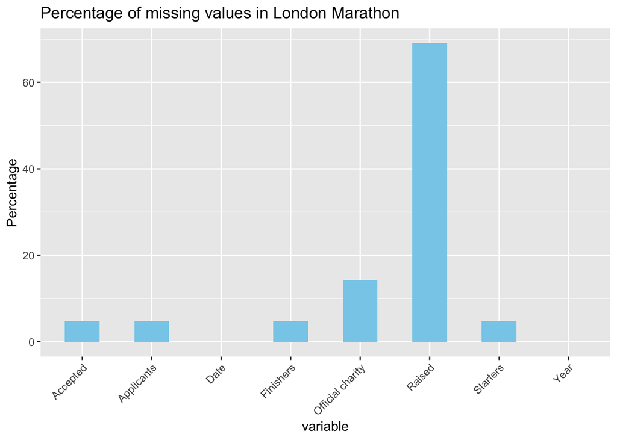

```r
missing_percentage <- colMeans(is.na(london_marathon)) * 100
plot_data <- data.frame(
  variable = names(missing_percentage),
  percentage = missing_percentage
)
ggplot(plot_data, aes(x = variable, y = percentage)) +
  geom_bar(stat = "identity", fill = "skyblue", width = 0.5) +
  labs(title = "Percentage of missing values in London Marathon", y = "Percentage") +
  theme(axis.text.x = element_text(angle = 45, hjust = 1))
```

So we can see that there are some missing values regarding the London Marathon.

the Raised means amount raised for charity (£ millions), and the Official charity means Official charity.

So we can think that if Official charity is NULL, it means there is no Official charity, then Raised should be 0 (or remove these values when analyzing Raised). If Official charity is not empty, and Raised is empty, then Raised Non-public, then we can fill it in using the average of other data.

For the missing other fields, we can see that the fields are the same. According to the official documentation (github), the data for the last two years is missing, so we should filter out the data for these two year (about london_marathon).

```r
london_marathon1 <- london_marathon %>% group_by(`Official charity`) %>% mutate(Raised=ifelse(is.na(Raised) & !is.na(`Official charity`), mean(london_marathon$Raised, na.rm=T), Raised))

london_marathon1 <- london_marathon1 %>% mutate(Raised=ifelse(is.na(`Official charity`), 0, Raised))

london_marathon1 <- london_marathon1 %>% mutate(`Official charity`=ifelse(is.na(`Official charity`), "None", `Official charity`))

london_marathon1 <- london_marathon1 %>% filter(Year < max(london_marathon1$Year) - 1)

cat("new missing value count:", sum(is.na(london_marathon1)))
```

```
## new missing value count: 0
```

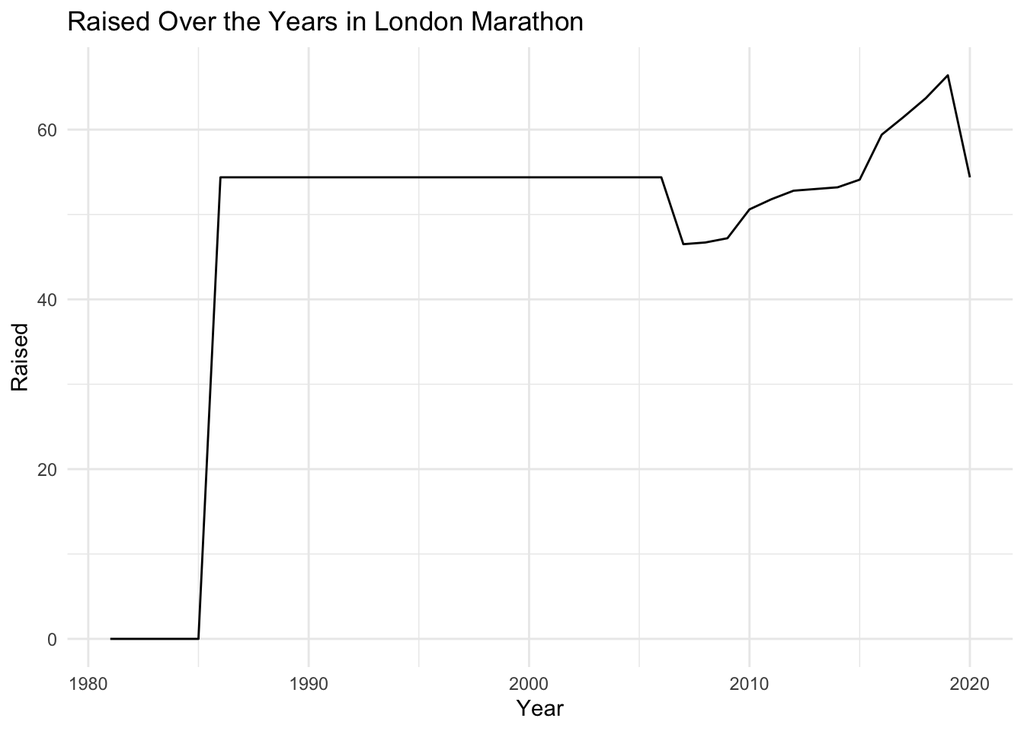

```r
ggplot(london_marathon1, aes(x = Year, y = Raised)) +
  geom_line() +
  labs(title = "Raised Over the Years in London Marathon",
       x = "Year",
       y = "Raised") +
  theme_minimal()
```

From the line chart, we can see that the Raised data we filled is not helpful in analyzing the changes in Raised data. If we want to analyze the changes in this part, we only need to focus on the data from 2007 to 2019.

```r
filter_data <- london_marathon1 %>% filter(Year >= 2007 & Year <= 2019)
filter_data
```

```
## # A tibble: 13 × 8
## # Groups:   Official charity [13]
##    Date        Year Applicants Accepted Starters Finishers Raised
##    <date>     <dbl>      <dbl>    <dbl>    <dbl>     <dbl>  <dbl>
##  1 2007-04-22  2007     128000    50039    36396     35729   46.5
##  2 2008-04-13  2008     120000    48630    35037     34637   46.7
##  3 2009-04-26  2009     155000    49995    35884     35404   47.2
##  4 2010-04-25  2010     163000    51378    36956     36666   50.6
##  5 2011-04-17  2011     163926    50532    35303     34872   51.8
##  6 2012-04-22  2012     170150    50200    37227     36812   52.8
##  7 2013-04-21  2013     167449    48323    34631     34381   53
##  8 2014-04-13  2014     169682    49872    36337     35977   53.2
##  9 2015-04-26  2015     172888    51696    38020     37793   54.1
## 10 2016-04-24  2016     247069    53152    39523     39140   59.4
## 11 2017-04-23  2017     253930    53229    40048     39487   61.5
## 12 2018-04-22  2018     386050    54685    40926     40220   63.7
## 13 2019-04-28  2019     414168    56398    42906     42549   66.4
## # ℹ 1 more variable: `Official charity` <chr>
```

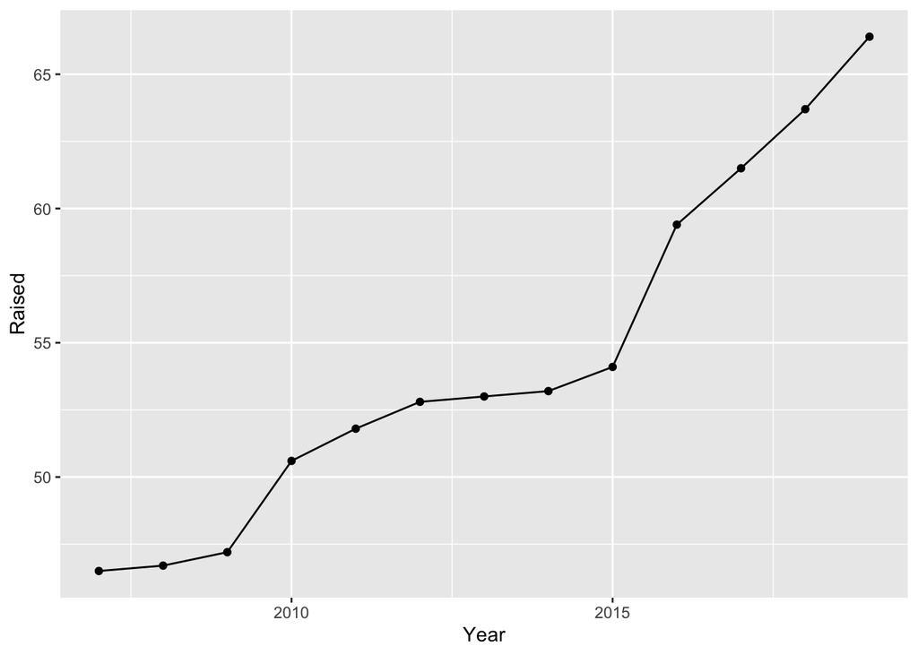

```r
ggplot(filter_data, aes(x=Year, y=Raised, group=1))+
  geom_line() +
  geom_point() +
  theme()
```

It can be seen that fundraising increases every year.

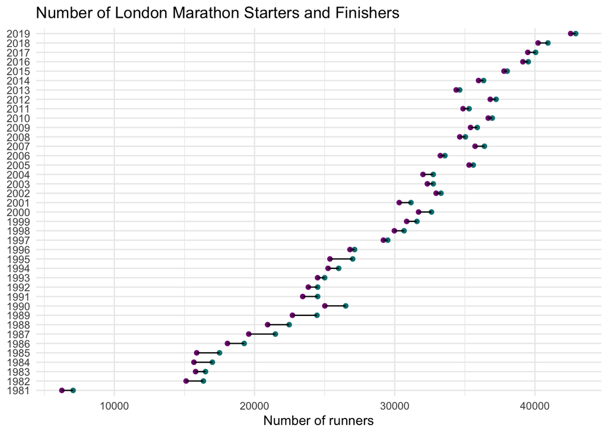

```r
# london marathon plot
london_plot <- london_marathon %>%
  filter(Year < 2020) %>%
  mutate(Year = factor(Year))

ggplot(
  data = london_plot,
  mapping = aes(y = Year)
) +
  geom_point(aes(x = Starters),
    colour = "#008080"
  ) +
  geom_point(aes(x = Finishers),
    colour = "#800080"
  ) +
  geom_segment(aes(
    x = Starters,
    xend = Finishers,
    y = Year,
    yend = Year
  )) +
  labs(
    x = "Number of runners",
    title = "Number of London Marathon Starters and Finishers"
  ) +
  theme_minimal() +
  theme(
    axis.title.y = element_blank(),
    plot.background = element_rect(fill = "white", colour = "white"),
    panel.background = element_rect(fill = "white", colour = "white")
  )
```

### Trends in number of applicants, accepted, starters, and finishers over year.

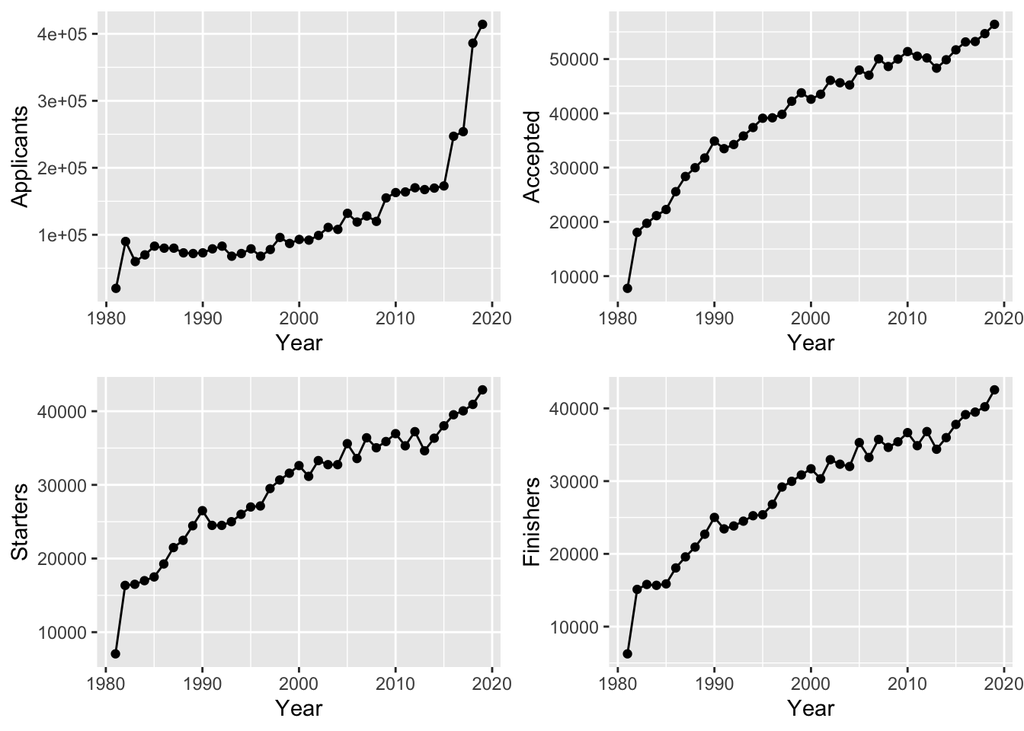

```r
par(mfrow=c(2,2))
sub_london <- london_marathon[1:39,]
p1 <- ggplot(data= sub_london, aes(x=Year, y=Applicants ))+geom_point()+geom_line()
p2 <- ggplot(data= sub_london, aes(x=Year, y=Accepted ))+geom_point()+geom_line()
p3 <- ggplot(data= sub_london, aes(x=Year, y=Starters ))+geom_point()+geom_line()
p4 <- ggplot(data= sub_london, aes(x=Year, y=Finishers))+geom_point()+geom_line()
grid.arrange(p1, p2, p3, p4, nrow=2, ncol=2)
```

### Linear models for applicants versus year, accepted versus year, starters versus year, and finishers versus year

```r
fit1 <- lm(Applicants ~ Year, data = sub_london)
fit2 <- lm(Accepted ~ Year, data = sub_london)
fit3 <- lm(Starters ~ Year, data = sub_london)
fit4 <- lm(Finishers ~ Year, data = sub_london)
summary(fit1)
```

```
##
## Call:
## lm(formula = Applicants ~ Year, data = sub_london)
##
## Residuals:
##    Min     1Q Median     3Q    Max
## -50350 -32201 -18679  22273 181509
##
## Coefficients:
##               Estimate Std. Error t value Pr(>|t|)
## (Intercept) -1.120e+07  1.430e+06  -7.833 2.27e-09 ***
## Year         5.664e+03  7.152e+02   7.920 1.75e-09 ***
## ---
## Signif. codes:  0 '***' 0.001 '**' 0.01 '*' 0.05 '.' 0.1 ' ' 1
##
## Residual standard error: 50270 on 37 degrees of freedom
## Multiple R-squared:  0.629,  Adjusted R-squared:  0.619
## F-statistic: 62.73 on 1 and 37 DF,  p-value: 1.748e-09
```

```r
summary(fit2)
```

```
##
## Call:
## lm(formula = Accepted ~ Year, data = sub_london)
##
## Residuals:
##    Min     1Q Median     3Q    Max
## -13932  -2994   1030   2447   4478
##
## Coefficients:
##               Estimate Std. Error t value Pr(>|t|)
## (Intercept) -1.917e+06  1.056e+05  -18.15   <2e-16 ***
## Year         9.787e+02  5.281e+01   18.53   <2e-16 ***
## ---
## Signif. codes:  0 '***' 0.001 '**' 0.01 '*' 0.05 '.' 0.1 ' ' 1
##
## Residual standard error: 3711 on 37 degrees of freedom
## Multiple R-squared:  0.9028, Adjusted R-squared:  0.9001
## F-statistic: 343.5 on 1 and 37 DF,  p-value: < 2.2e-16
```

```r
summary(fit3)
```

```
##
## Call:
## lm(formula = Starters ~ Year, data = sub_london)
##
## Residuals:
##    Min     1Q Median     3Q    Max
##  -9512  -1084    258   1076   3748
##
## Coefficients:
##               Estimate Std. Error t value Pr(>|t|)
## (Intercept) -1.345e+06  6.658e+04  -20.20   <2e-16 ***
## Year         6.873e+02  3.329e+01   20.64   <2e-16 ***
## ---
## Signif. codes:  0 '***' 0.001 '**' 0.01 '*' 0.05 '.' 0.1 ' ' 1
##
## Residual standard error: 2340 on 37 degrees of freedom
## Multiple R-squared:  0.9201, Adjusted R-squared:  0.918
## F-statistic: 426.2 on 1 and 37 DF,  p-value: < 2.2e-16
```

```r
summary(fit4)
```

```
##
## Call:
## lm(formula = Finishers ~ Year, data = sub_london)
##
## Residuals:
##     Min      1Q  Median      3Q     Max
## -8999.6 -1040.2    93.8  1163.7  3311.4
##
## Coefficients:
##               Estimate Std. Error t value Pr(>|t|)
## (Intercept) -1.404e+06  6.518e+04  -21.54   <2e-16 ***
## Year         7.163e+02  3.259e+01   21.98   <2e-16 ***
## ---
## Signif. codes:  0 '***' 0.001 '**' 0.01 '*' 0.05 '.' 0.1 ' ' 1
##
## Residual standard error: 2291 on 37 degrees of freedom
## Multiple R-squared:  0.9289, Adjusted R-squared:  0.9269
## F-statistic: 483.1 on 1 and 37 DF,  p-value: < 2.2e-16
```

### Create new variables(ratios of accepted, starters, and finishers) and visulization

```r
london_marathon <- london_marathon |> mutate(`Ratio of Accepted`=Accepted/Applicants)|>mutate(`Ratio of Starters`=Starters/Accepted)|> mutate(`Ratio of Finishers`=Finishers/Starters)
print(london_marathon[, c("Year", "Ratio of Accepted", "Ratio of Starters","Ratio of Finishers")])
```

```
## # A tibble: 42 × 4
##     Year `Ratio of Accepted` `Ratio of Starters` `Ratio of Finishers`
##    <dbl>               <dbl>               <dbl>                <dbl>
##  1  1981               0.387               0.911                0.887
##  2  1982               0.201               0.905                0.925
##  3  1983               0.329               0.836                0.957
##  4  1984               0.302               0.804                0.922
##  5  1985               0.268               0.786                0.907
##  6  1986               0.320               0.753                0.938
##  7  1987               0.355               0.757                0.912
##  8  1988               0.411               0.749                0.932
##  9  1989               0.441               0.770                0.928
## 10  1990               0.478               0.760                0.944
## # ℹ 32 more rows
```

Notable Observation (2020):

In 2020, there’s a notable observation in the “Accepted to Started” column. The percentage is 100%, indicating that all accepted participants started the race. However, the “Started to Finished” percentage is lower (79.22%), indicating that not all starters completed the race.

This discrepancy could be due to the impact of external factors such as the COVID-19 pandemic, leading to a different pattern in that particular year.

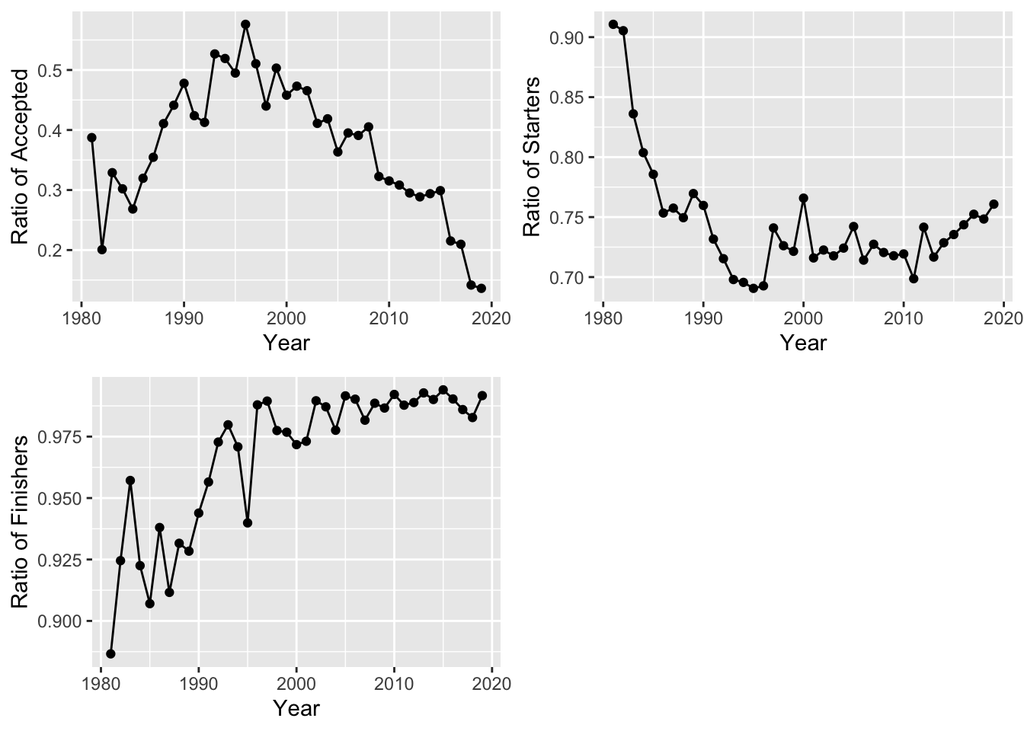

```r
sub_london1 <- london_marathon[1:39,]
p1 <- ggplot(data= sub_london1, aes(x=Year, y=`Ratio of Accepted` ))+geom_point()+geom_line()
p2 <- ggplot(data= sub_london1, aes(x=Year, y=`Ratio of Starters` ))+geom_point()+geom_line()
p3 <- ggplot(data= sub_london1, aes(x=Year, y=`Ratio of Finishers` ))+geom_point()+geom_line()
grid.arrange(p1, p2, p3, nrow=2, ncol=2)
```

### Time series analysis and forecasting

```r
plotForecastErrors <- function(forecasterrors)
  {
     # make a histogram of the forecast errors:
     mybinsize <- IQR(forecasterrors)/4
     mysd   <- sd(forecasterrors)
     mymin  <- min(forecasterrors) - mysd*5
     mymax  <- max(forecasterrors) + mysd*3
     # generate normally distributed data with mean 0 and standard deviation mysd
     mynorm <- rnorm(10000, mean=0, sd=mysd)
     mymin2 <- min(mynorm)
     mymax2 <- max(mynorm)
     if (mymin2 < mymin) { mymin <- mymin2 }
     if (mymax2 > mymax) { mymax <- mymax2 }
     # make a red histogram of the forecast errors, with the normally distributed data overlaid:
     mybins <- seq(mymin, mymax, mybinsize)
     hist(forecasterrors, col="red", freq=FALSE, breaks=mybins)
     # freq=FALSE ensures the area under the histogram = 1
     # generate normally distributed data with mean 0 and standard deviation mysd
     myhist <- hist(mynorm, plot=FALSE, breaks=mybins)
     # plot the normal curve as a blue line on top of the histogram of forecast errors:
     points(myhist$mids, myhist$density, type="l", col="blue", lwd=2)
}
```

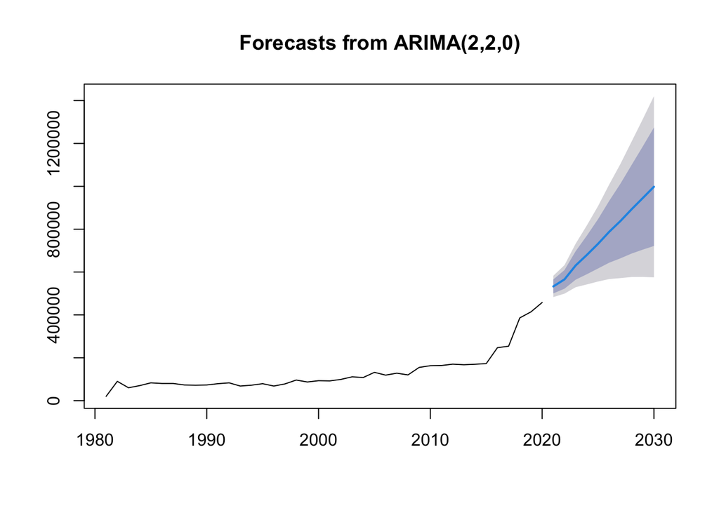

```r
app <- london_marathon$Applicants[1:40]
appts <- ts(app, ,frequency=1,start=1981)
appts <- na.omit(appts)
apptsarima <- auto.arima(appts)
fc <- forecast(apptsarima, h=10)
plot(fc)
```

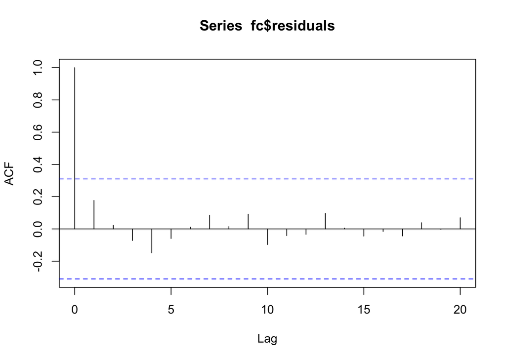

```r
acf(fc$residuals, lag.max=20)
```

```r
Box.test(fc$residuals, lag=20, type="Ljung-Box")
```

```
##
##  Box-Ljung test
##
## data:  fc$residuals
## X-squared = 5.7183, df = 20, p-value = 0.9992
```

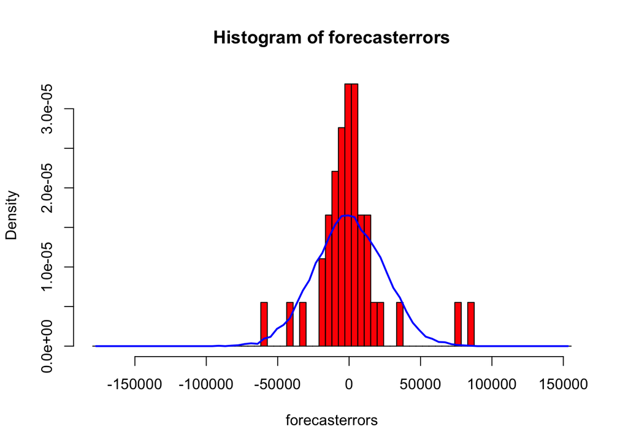

```r
plotForecastErrors(fc$residuals)
```

#### Ratio of Accepted

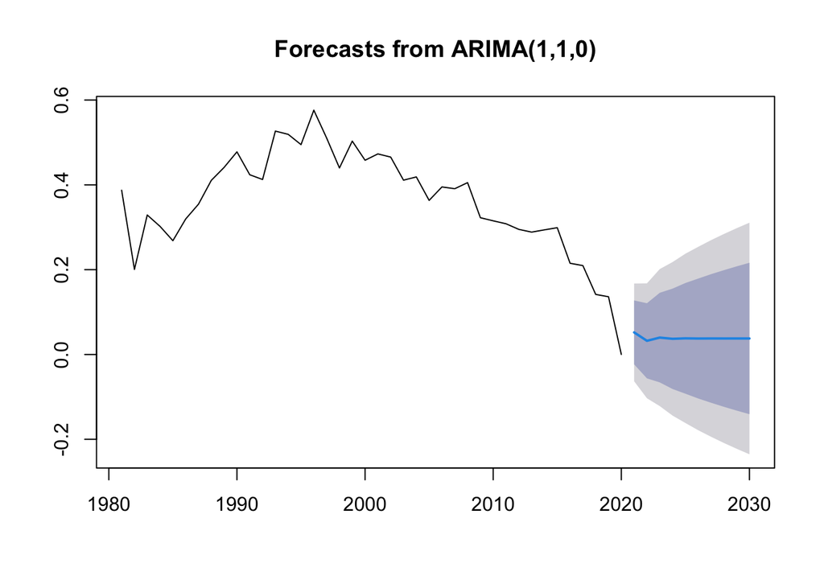

```r
roa <- london_marathon$`Ratio of Accepted`
roats <- ts(roa, ,frequency=1,start=1981)
roats<- na.omit(roats)
roatsarima <- auto.arima(roats)
fc2 <- forecast(roatsarima, h=10)
plot(fc2)
```

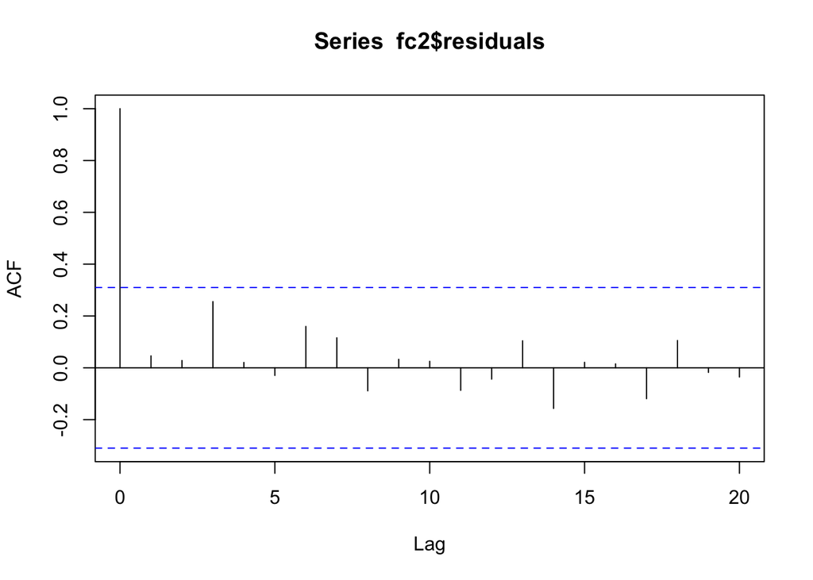

```r
acf(fc2$residuals, lag.max=20)
```

```r
Box.test(fc2$residuals, lag=20, type="Ljung-Box")
```

```
##
##  Box-Ljung test
##
## data:  fc2$residuals
## X-squared = 10.473, df = 20, p-value = 0.9588
```

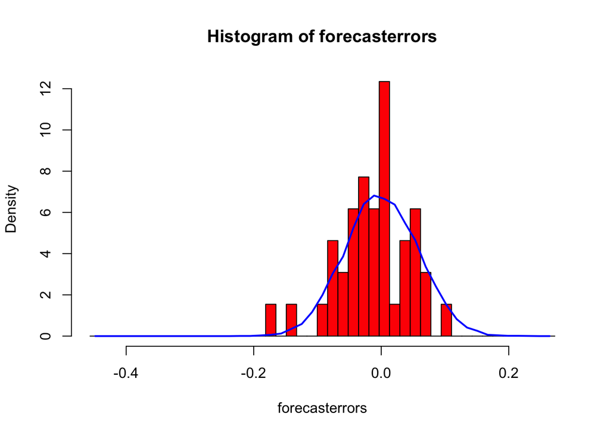

```r
plotForecastErrors(fc2$residuals)
```

#### Ratio of Starters

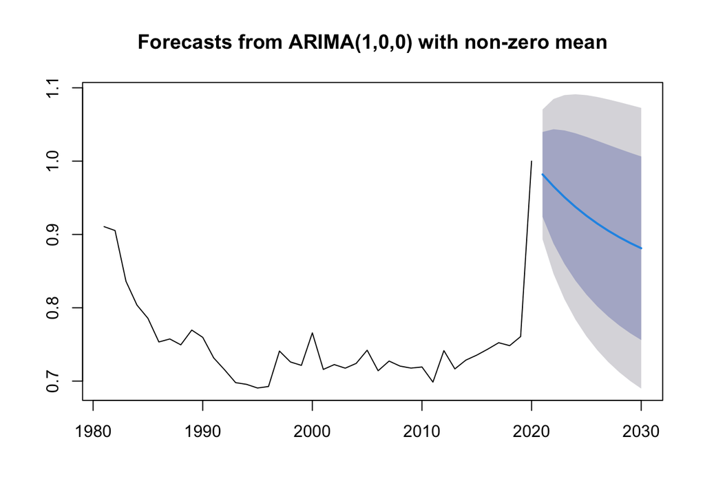

```r
ros <- london_marathon$`Ratio of Starters`
rosts <- ts(ros, ,frequency=1,start=1981)
rosts <- na.omit(rosts)
rostsarima <- auto.arima(rosts)
fc2 <- forecast(rostsarima, h=10)
plot(fc2)
```

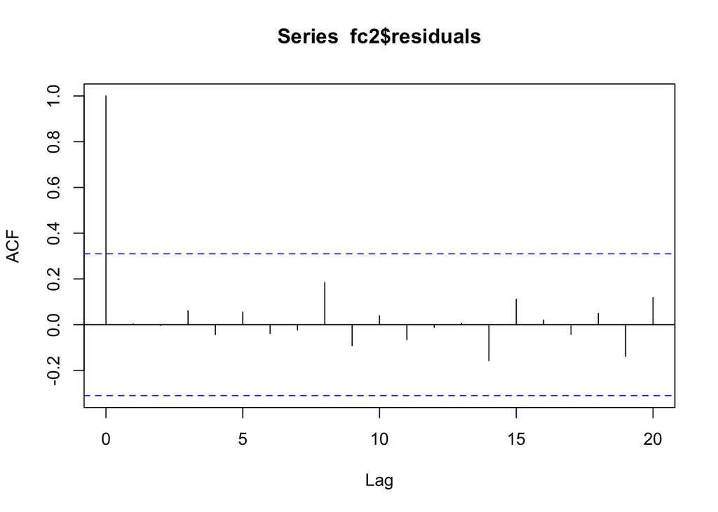

```r
acf(fc2$residuals, lag.max=20)
```

```r
Box.test(fc2$residuals, lag=20, type="Ljung-Box")
```

```
##
##  Box-Ljung test
##
## data:  fc2$residuals
## X-squared = 8.5628, df = 20, p-value = 0.9874
```

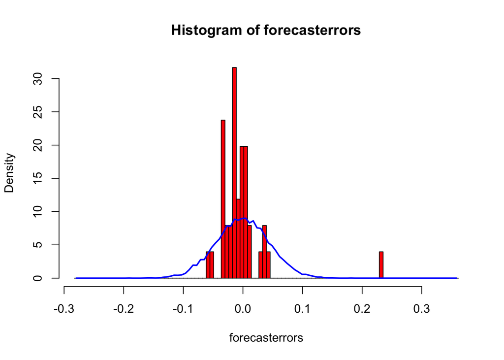

```r
plotForecastErrors(fc2$residuals)
```

#### Ratio of Finishers

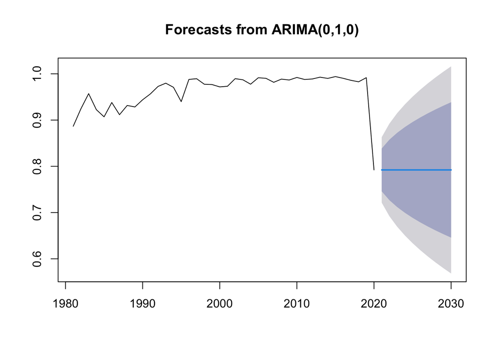

```r
rof <- london_marathon$`Ratio of Finishers`
rofts <- ts(rof, ,frequency=1,start=1981)
rofts <- na.omit(rofts)
roftsarima <- auto.arima(rofts)
fc <- forecast(roftsarima, h=10)
plot(fc)
```

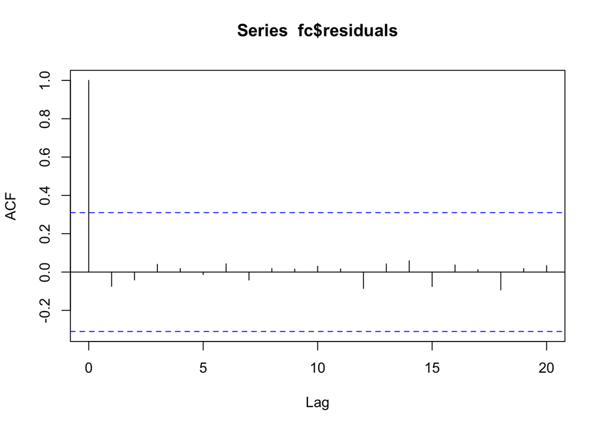

```r
acf(fc$residuals, lag.max=20)
```

```r
Box.test(fc$residuals, lag=20, type="Ljung-Box")
```

```
##
##  Box-Ljung test
##
## data:  fc$residuals
## X-squared = 2.745, df = 20, p-value = 1
```

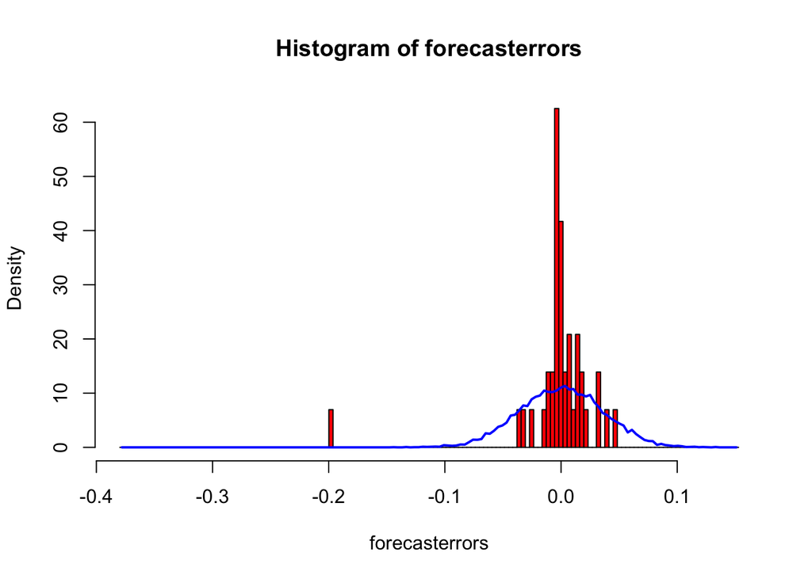

```r
plotForecastErrors(fc$residuals)
```

## Clarification

Though there are some overlaps between our team members works, we came up the question independently and did the analysis independently. The report is an integration of our work. Here are the jobs that we did:

#### Longxiang Wu

data wrangling part  
winner dataset  
- plot of time versus year  
- boxplots of time based on category  
- analysis of difference of athletes’ performance based on nationality  
- analysis of difference between performance of men and women  
- summarising coutries that have the most winners  
london_marathon dataset  
- plots of variables(applicants,accepted,starters,finishers) versus year  
- creating and plots of new variables  
- linear models for the dataset  
- time series analysis and forecasting  
integrated team’s works and composed report V1.0

#### Navpreet Singh Sandhu

introduction part  
winner dataset  
- analyzing trends in winning times over the year  
- comparing winning times between different categories  
- exploring potential correlations between winning times and other variables  
london_marathon dataset  
- creating new variables